# CFA project

Kevin Greenberg

12/14/2020

# Purpose

The goal of the Confirmatory factor analysis (CFA) project is to determine the accuracy and reliability of a survey that was developed to differentiate between people who were the first born child and not the first born child. The survey came from a scale (First Born Personality scale, (FBPS Scale v1.0)) created by a group wanting to look at the differences in responses on the first born survey in relation to personality surveys in the FBPS scale v1.0. This CFA project only focuses on the First born survey. For the development of this survey, the survey makers began with 375 items and narrowed the scale down to 26 questions as these 26 questions had the largest correlations to confirm the difference between first born and non-first born individuals. From a psychometric viewpoint this is an inadequate method to analyze the accuracy and reliability of a survey. As such, this project will examine the data from First born survey to determine if the survey can reliably and accurately differentiate between first born respondents and non-first born respondents. To do so, CFA analyses and Cronbach’s alphas are run.

## Data information

The data was collected on the internet between April 2019 and June 2019 and at the end of the survey, all survey takers were asked if they would like their answers to be used in research. This dataset only includes those who agreed (*N* = 41,841). No details are given on the demographics of the survey takers. Lastly, the survey had 26 Likert rated items presented on one page (1=Disagree, 3=Neutral, 5=Agree).

# Overview of data

```r
knitr::opts_chunk$set(echo = TRUE, cache = TRUE, comment = "", tidy = TRUE)

#Load package for data cleaning and plots
library(tidyverse)
#load packages for CFA and Cronbach's alpha
library(lavaan)
library(psych)
library(knitr)
library(semPlot)


#Load data
fb <- read.delim("C:/Users/kevin/Desktop/Portfolio/CFA/docs/FBPS-ValidationData.csv")
```

In the below table we see that 20,571 of the respondents were the first born child. The range in birth position is from 0th to 11th born. However, the survey was designed for determining birth position in families with 1 to 4 children. That being we must reduce the data set to only include families with 1 to 4 children. Lastly, all respondents who reported being the 0th born are also removed from the data set.

```r
knitr:: kable(table(fb$birthpos), booktabs = TRUE, format = "markdown")
```

| Var1 | Freq |
| --- | --- |
| 0 | 277 |
| 1 | 20571 |
| 2 | 12260 |
| 3 | 5232 |
| 4 | 1815 |
| 5 | 715 |
| 6 | 302 |
| 7 | 170 |
| 8 | 89 |
| 9 | 49 |
| 10 | 35 |
| 11 | 326 |

*Note*: Var1 = Birth position; Freq = How many respondents reported the respective birth position.

With the data set cleaned there are still 20571 first born respondents and now 19307 non-first born respondents (people born as the 2nd through 4th child). This reduces the data set to 39878 and there is an approximately even number of respondents by birth position, based on a binary scale (0 = non-first born; 1 = first born). There are also no missing data in the data set (a rarity in typical data but this data has already been cleaned prior to being made available online).

## Plot

Next we will plot the difference in responses between first born and non-first born respondents. Based on the small magnitude of difference in overall responses to First born survey, it gives an indication that using a survey to parse first born and non-first born respondents is a very difficult task.

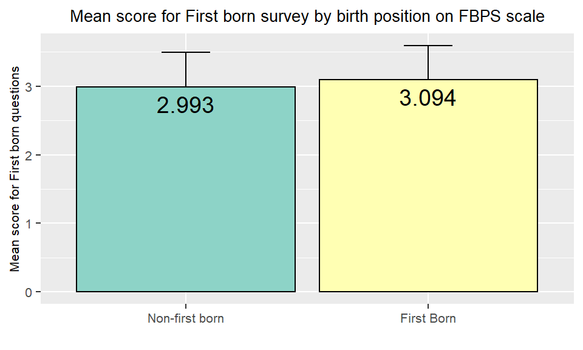

```r
ggplot(df1, aes(x=as.factor(birthpos), y=mean, fill=as.factor(birthpos))) +
  geom_bar(position=position_dodge(), stat="identity", colour='black') +
  geom_errorbar(aes(ymin=mean, ymax=mean+sd), width=.2)  +
  geom_text(aes(label = mean), size = 5, vjust = 1.5) +
  xlab("") + ylab("Mean score for First born questions") +
  ggtitle("Mean score for First born survey by birth position on FBPS scale") +
  theme(legend.position = "none") +
  theme(plot.title = element_text (size=10, hjust = 0.5))+
  theme(axis.text=element_text(size=8),
        axis.title=element_text(size=8))+
  scale_fill_brewer(palette="Set3")
```

*Note*: Colors are chosen as red-green color blind friendly

# Data analysis

## CFA for the First Born questions

```r
fb1 <- fb[,c(1:26, 30)]
RNGversion("4.0.3"); set.seed(123)
rand_sample <- sample(39878, 200)
##get the initial training df
fb1 <- fb1[rand_sample, ]
```

The cleaned data set has an *N* = 39,878, which is a huge sample for a CFA mainly because it will inflate the estimates. Therefore, the data set is reduced to 200 random respondents. There are 107 first born respondents, indicating a roughly even random split of respondents.

Additionally, it is important to standardized the questions in the survey because this creates more accurate estimates of the data. There are two ways of standardizing. The first is scaling via the Latent variable. However, if there is variance between the questions (a lack homogeneity of variance), then it is more common and accurate to standardize through a marker variable. Therefore, to take the more cautious approach, we will use the marker variable model. To indicate what question will be the best marker variable we will use an indicator model that scales based on the latent variables. The marker variable is the questions that has the estimate closest to 1.0.

## Indicating the marker variable to standardize the CFA model

For the first born factor, Q3 is the best marker variable as it has an estimate of .965. While Q21 has an estimate of .845 indicating it as the best marker variable for the non-first born factor. “FB” is the latent variable for first born questions and “NFB” is the latent variable for non-first born questions.

```r
fbQ.model1 <- "FB =~  Q1+ Q2 + Q3 + Q4 + Q6 + Q7 + Q8 + Q9 + Q10 + Q11 +
Q12 + Q13 + Q14 + Q15 + Q16 + Q17 + Q19 + Q20 + Q23 + Q24 + Q26

NFB =~ Q5 + Q18 + Q21 + Q22 + Q25

FB ~~ 1*FB
NFB ~~ 1*NFB
"

fitQ1 <- lavaan::cfa(fbQ.model1, data=fb1,std.lv=TRUE)
summary(fitQ1, fit.measures=T,standardized=T)
```

```
lavaan 0.6-7 ended normally after 25 iterations

  Estimator                                         ML
  Optimization method                           NLMINB
  Number of free parameters                         53

  Number of observations                           200

Model Test User Model:

  Test statistic                               629.317
  Degrees of freedom                               298
  P-value (Chi-square)                           0.000

Model Test Baseline Model:

  Test statistic                              1447.296
  Degrees of freedom                               325
  P-value                                        0.000

User Model versus Baseline Model:

  Comparative Fit Index (CFI)                    0.705
  Tucker-Lewis Index (TLI)                       0.678

Loglikelihood and Information Criteria:

  Loglikelihood user model (H0)              -8188.603
  Loglikelihood unrestricted model (H1)      -7873.945

  Akaike (AIC)                               16483.207
  Bayesian (BIC)                             16658.017
  Sample-size adjusted Bayesian (BIC)        16490.108

Root Mean Square Error of Approximation:

  RMSEA                                          0.075
  90 Percent confidence interval - lower         0.066
  90 Percent confidence interval - upper         0.083
  P-value RMSEA <= 0.05                          0.000
```

[output cut: 62 more lines]

```
   .Q13               1.354    0.135    9.996    0.000    1.354    0.997
   .Q14               1.596    0.164    9.712    0.000    1.596    0.801
   .Q15               1.451    0.146    9.922    0.000    1.451    0.937
   .Q16               0.981    0.104    9.407    0.000    0.981    0.663
   .Q17               1.027    0.103    9.991    0.000    1.027    0.992
   .Q19               1.450    0.145    9.970    0.000    1.450    0.975
   .Q20               1.493    0.149    9.992    0.000    1.493    0.993
   .Q23               0.745    0.076    9.761    0.000    0.745    0.829
   .Q24               1.649    0.166    9.926    0.000    1.649    0.940
   .Q26               2.333    0.234    9.957    0.000    2.333    0.964
   .Q5                0.925    0.140    6.590    0.000    0.925    0.655
   .Q18               1.371    0.144    9.497    0.000    1.371    0.922
   .Q21               1.014    0.183    5.534    0.000    1.014    0.587
   .Q22               1.691    0.172    9.848    0.000    1.691    0.975
   .Q25               1.497    0.150    9.990    0.000    1.497    0.998
```

## Full CFA model

The output for the full CFA model with marker variable shows an SRMR around .08 is adequate fit, but .05 is good fit. So we see and SRMR = .080, indicating below adequate fit. Also, RMSEA at or below .05 is a good fit, while below .08 is an adequate fit, and above .10 is a bad fit (Brown & Cudeck, 1993). Here our model has an RMSEA = .074, indicating an adequate fit. CFI and TLI are also good indicators of fit with better fit being close to 1, and our model has a CFI = .705 and TLI = .681, both indicating a poor fit. A significant chi-square indicates a poor fit, but chi-squared is not the most useful fit indices because with skewed data we see increased chi-squared. AIC/BIC is only useful for comparing models with lower AIC indicating better fit.

Looking at the estimates in the Marker variable model we have a few items where the loading is below .4, which is considered poor (Tabachnick & Fidell, 2011). In this case we can remove the items and conduct a reduced CFA model (From First born questions, removed Q2, Q13, Q15, & Q17, Q19 - Q26 (From Non-first born questions removed Q18, Q22, Q25)

```r
fbQ.model2 <- "FB =~  Q1+ Q2 + 1*Q3 + Q4 + Q6 + Q7 + Q8 + Q9 + Q10 + Q11 +
Q12 + Q13 + Q14 + Q15 + Q16 + Q17 + Q19 + Q20 + Q23 + Q24 + Q26

NFB =~ Q5 + Q18 + 1*Q21 + Q22 + Q25"

#1*Q3 Makes Q7 the marker variable for FB
#1*Q21 Makes Q21 the marker variable NFB
#FB and NFB are by default already correlated


fitQ2 <- lavaan::cfa(fbQ.model2, data=fb1,std.lv=TRUE)
summary(fitQ2, fit.measures=T,standardized=T)
```

```
lavaan 0.6-7 ended normally after 22 iterations

  Estimator                                         ML
  Optimization method                           NLMINB
  Number of free parameters                         51

  Number of observations                           200

Model Test User Model:

  Test statistic                               630.874
  Degrees of freedom                               300
  P-value (Chi-square)                           0.000

Model Test Baseline Model:

  Test statistic                              1447.296
  Degrees of freedom                               325
  P-value                                        0.000

User Model versus Baseline Model:

  Comparative Fit Index (CFI)                    0.705
  Tucker-Lewis Index (TLI)                       0.681

Loglikelihood and Information Criteria:

  Loglikelihood user model (H0)              -8189.382
  Loglikelihood unrestricted model (H1)      -7873.945

  Akaike (AIC)                               16480.764
  Bayesian (BIC)                             16648.978
  Sample-size adjusted Bayesian (BIC)        16487.405

Root Mean Square Error of Approximation:

  RMSEA                                          0.074
  90 Percent confidence interval - lower         0.066
  90 Percent confidence interval - upper         0.082
  P-value RMSEA <= 0.05                          0.000
```

[output cut: 62 more lines]

```
   .Q15               1.451    0.146    9.923    0.000    1.451    0.935
   .Q16               0.979    0.104    9.406    0.000    0.979    0.653
   .Q17               1.027    0.103    9.991    0.000    1.027    0.992
   .Q19               1.450    0.145    9.971    0.000    1.450    0.974
   .Q20               1.493    0.149    9.992    0.000    1.493    0.993
   .Q23               0.745    0.076    9.761    0.000    0.745    0.824
   .Q24               1.649    0.166    9.927    0.000    1.649    0.938
   .Q26               2.333    0.234    9.958    0.000    2.333    0.963
   .Q5                0.990    0.129    7.703    0.000    0.990    0.690
   .Q18               1.385    0.144    9.625    0.000    1.385    0.928
   .Q21               0.856    0.152    5.638    0.000    0.856    0.461
   .Q22               1.692    0.171    9.873    0.000    1.692    0.974
   .Q25               1.498    0.150    9.995    0.000    1.498    0.999
    FB                1.000                               1.000    1.000
    NFB               1.000                               1.000    1.000
```

## Reduced CFA model

Below are the results for the reduced CFA model. In the reduced model our SRMR decreased to SRMR = 0.067, indicating a better fit. However, the RMSEA = .085, increased but still suggests an adequate fit. The CFI = .862 and TLI = .839, both suggesting a more adequate model. It appears that the reduced model is a better fit based on the CFA results. RMSEA did increase in the reduced model, most likely due to removing many parameters from the model(i.e. questions from the survey). RMSEA is sensitive to the number of parameters. Yet, based on the SRMR, CFI and TLI, which are recommended fit indices for CFA (Hu & Bentler, 1998), the reduced model is a better fit.

```r
#Reduced Marker variable model
fbQ.model3 <- "FB =~  Q1 + 1*Q3 + Q4 + Q6 + Q7 + Q8 + Q9 + Q10 + Q11 +
Q12 + Q14 + Q16

NFB =~ Q5 + 1*Q21"

fitQ3 <- lavaan::cfa(fbQ.model3, data=fb1,std.lv=TRUE)
summary(fitQ3, fit.measures=T,standardized=T)
```

```
lavaan 0.6-7 ended normally after 20 iterations

  Estimator                                         ML
  Optimization method                           NLMINB
  Number of free parameters                         27

  Number of observations                           200

Model Test User Model:

  Test statistic                               191.761
  Degrees of freedom                                78
  P-value (Chi-square)                           0.000

Model Test Baseline Model:

  Test statistic                               917.610
  Degrees of freedom                                91
  P-value                                        0.000

User Model versus Baseline Model:

  Comparative Fit Index (CFI)                    0.862
  Tucker-Lewis Index (TLI)                       0.839

Loglikelihood and Information Criteria:

  Loglikelihood user model (H0)              -4301.935
  Loglikelihood unrestricted model (H1)      -4206.055

  Akaike (AIC)                                8657.870
  Bayesian (BIC)                              8746.925
  Sample-size adjusted Bayesian (BIC)         8661.386

Root Mean Square Error of Approximation:

  RMSEA                                          0.085
  90 Percent confidence interval - lower         0.070
  90 Percent confidence interval - upper         0.101
  P-value RMSEA <= 0.05                          0.000
```

[output cut: 38 more lines]

```
   .Q3                0.677    0.081    8.354    0.000    0.677    0.404
   .Q4                1.708    0.173    9.861    0.000    1.708    0.894
   .Q6                1.545    0.159    9.708    0.000    1.545    0.802
   .Q7                0.634    0.076    8.306    0.000    0.634    0.413
   .Q8                0.443    0.057    7.744    0.000    0.443    0.345
   .Q9                0.837    0.092    9.049    0.000    0.837    0.554
   .Q10               1.233    0.128    9.662    0.000    1.233    0.777
   .Q11               1.123    0.119    9.402    0.000    1.123    0.664
   .Q12               1.553    0.157    9.878    0.000    1.553    0.906
   .Q14               1.595    0.164    9.696    0.000    1.595    0.795
   .Q16               0.992    0.106    9.398    0.000    0.992    0.662
   .Q5                1.040    0.131    7.939    0.000    1.040    0.729
   .Q21               0.820    0.157    5.228    0.000    0.820    0.450
    FB                1.000                               1.000    1.000
    NFB               1.000                               1.000    1.000
```

## CFA plots

The plots show that the full model has poor estimates of the 2 factors, as indicated by the negative loadings. While the plot for the reduced CFA model shows a more accurate fit of the data.

### Full CFA Model

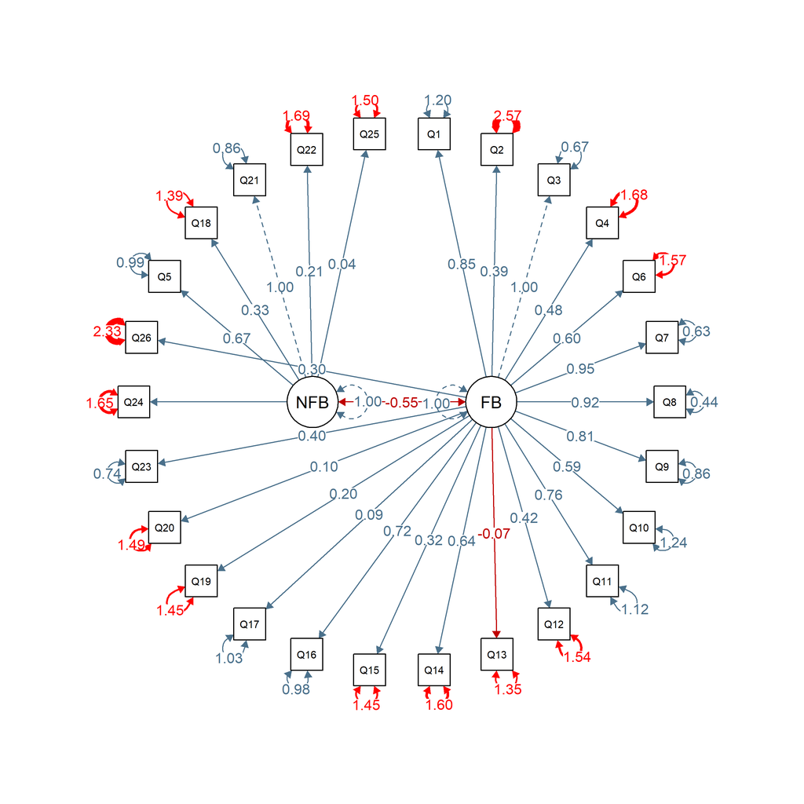

```r
semPaths(fitQ2, "par", posCol=c("skyblue4", "red"),
         edge.label.cex = .75, fade = F, node.width = .75,
         asize = 2, layout = "circle")
```

### Reduced CFA Model

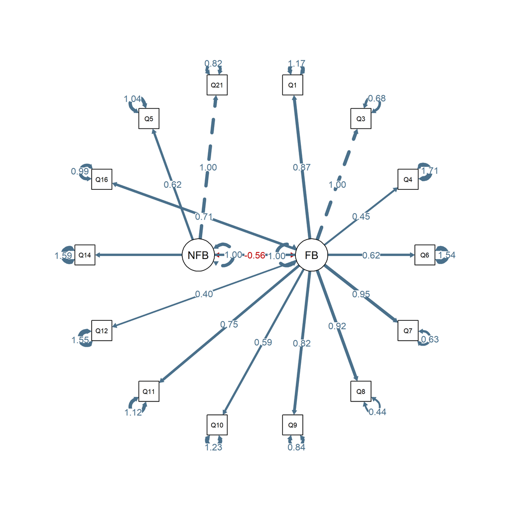

```r
semPaths(fitQ3, "par", posCol=c("skyblue4", "red"),
         edge.label.cex = .75, fade = F, node.width = .75,
         asize = 2, layout = "circle")
```

Also to note, it does not make sense to compare the above two models(via anova function) because although both models use the same data set, models have a different number of items/variable reduced they are working with different sets of observed variables.

## Cronbach’s alpha

### Full model Cronbach’s alpha

When all 26 questions are included, the results indicate a Cronbach’s alpha of .79 which is acceptable. The survey developers did not conduct a reliability check, rather picked the questions with the highest correlation. However, if they did run this reliability check, they may interpret the results as having created a reliable measure. When looking at the results the reliability check appears accurate as the 5 items that are supposed to be reversed scored (load onto the non-first born factor; Q5, Q18, Q21, Q22, & Q25) are indicated in the output. However, Q13 is also reversed scored, but it should not be scored in such manner. This is a case where the Cronbach’s alphas all indicate a reliable model, while the CFA model indicates a poor fit(Shelby, 2011). Therefore, based on the reduced CFA model we will remove a few questions and re-analyze the Cronbach’s alpha.

```r
fbQ1ca <- select(fb1, Q1,Q2 ,Q3 ,Q4 ,Q5 ,Q6 ,Q7 ,Q8 ,Q9 ,Q10 ,Q11 ,Q12 ,Q13
                 ,Q14 ,Q15 ,Q16 ,Q17 ,Q18 ,Q19 ,Q20 ,Q21 ,Q22 ,Q23 ,Q24 ,Q25 ,Q26)

alpha(fbQ1ca, check.keys = TRUE)
```

```
Reliability analysis
Call: alpha(x = fbQ1ca, check.keys = TRUE)

  raw_alpha std.alpha G6(smc) average_r S/N  ase mean   sd median_r
      0.79      0.79    0.85      0.13 3.9 0.02  2.8 0.52     0.11

 lower alpha upper     95% confidence boundaries
0.75 0.79 0.83

 Reliability if an item is dropped:
     raw_alpha std.alpha G6(smc) average_r S/N alpha se var.r med.r
Q1        0.78      0.78    0.83      0.12 3.5    0.022 0.022 0.106
Q2        0.79      0.79    0.84      0.13 3.8    0.020 0.024 0.108
Q3        0.77      0.77    0.83      0.12 3.3    0.023 0.021 0.102
Q4        0.78      0.79    0.84      0.13 3.7    0.021 0.024 0.104
Q5-       0.78      0.79    0.84      0.13 3.7    0.021 0.024 0.106
Q6        0.79      0.79    0.84      0.13 3.7    0.021 0.023 0.110
Q7        0.77      0.77    0.82      0.12 3.4    0.023 0.021 0.098
Q8        0.77      0.77    0.82      0.12 3.3    0.023 0.020 0.098
Q9        0.78      0.78    0.83      0.12 3.5    0.022 0.022 0.106
Q10       0.78      0.79    0.84      0.13 3.7    0.021 0.023 0.108
Q11       0.78      0.78    0.83      0.12 3.5    0.022 0.022 0.102
Q12       0.78      0.79    0.84      0.13 3.7    0.021 0.024 0.106
Q13-      0.80      0.80    0.85      0.14 4.0    0.020 0.023 0.117
Q14       0.78      0.79    0.84      0.13 3.7    0.021 0.023 0.104
Q15       0.79      0.79    0.84      0.13 3.8    0.021 0.024 0.110
Q16       0.78      0.78    0.83      0.12 3.5    0.022 0.022 0.104
Q17       0.80      0.80    0.85      0.14 4.0    0.020 0.023 0.118
Q18-      0.79      0.80    0.85      0.14 3.9    0.020 0.024 0.116
Q19       0.80      0.80    0.85      0.14 4.0    0.020 0.023 0.114
Q20       0.80      0.80    0.85      0.14 4.0    0.020 0.023 0.118
Q21-      0.78      0.79    0.84      0.13 3.7    0.021 0.024 0.106
Q22-      0.80      0.80    0.85      0.14 4.1    0.020 0.023 0.118
Q23       0.79      0.79    0.84      0.13 3.7    0.021 0.024 0.106
Q24       0.79      0.79    0.84      0.13 3.7    0.021 0.024 0.106
Q25-      0.80      0.80    0.85      0.14 4.0    0.020 0.023 0.116
Q26       0.79      0.79    0.84      0.13 3.8    0.020 0.024 0.114

 Item statistics
       n raw.r std.r r.cor r.drop mean   sd
```

[output cut: 40 more lines]

```
Q12 0.01 0.09 0.12 0.17 0.34 0.26    0
Q13 0.00 0.22 0.37 0.17 0.19 0.04    0
Q14 0.00 0.24 0.26 0.16 0.18 0.15    0
Q15 0.01 0.14 0.40 0.22 0.10 0.12    0
Q16 0.00 0.06 0.17 0.18 0.34 0.23    0
Q17 0.00 0.56 0.20 0.16 0.04 0.02    0
Q18 0.00 0.09 0.18 0.23 0.32 0.17    0
Q19 0.01 0.07 0.23 0.22 0.32 0.16    0
Q20 0.00 0.11 0.40 0.18 0.18 0.12    0
Q21 0.01 0.24 0.28 0.17 0.22 0.09    0
Q22 0.00 0.16 0.23 0.17 0.30 0.13    0
Q23 0.00 0.01 0.04 0.16 0.43 0.35    0
Q24 0.00 0.20 0.23 0.20 0.26 0.12    0
Q25 0.01 0.06 0.17 0.21 0.32 0.23    0
Q26 0.01 0.38 0.19 0.06 0.20 0.16    0
```

### Reduced model Cronbach’s alpha

With the reduced number of questions, the Cronbach’s alpha is .84, which is good reliability and higher than the previous analysis. The more important aspect is looking at the questions that are reversed scored, in this case all the questions that are reversed scored are supposed to be based on the reduced CFA model and the intentions of the survey developers.

```r
fbQ2ca <-  select(fb1, Q1, Q3, Q4, Q5, Q6, Q7, Q8, Q9, Q10, Q11, Q12, Q14, Q16, Q21)
alpha(fbQ2ca, check.keys = TRUE)
```

```
Reliability analysis
Call: alpha(x = fbQ2ca, check.keys = TRUE)

  raw_alpha std.alpha G6(smc) average_r S/N   ase mean   sd median_r
      0.84      0.85    0.87      0.28 5.5 0.016  3.1 0.74     0.27

 lower alpha upper     95% confidence boundaries
0.81 0.84 0.87

 Reliability if an item is dropped:
     raw_alpha std.alpha G6(smc) average_r S/N alpha se var.r med.r
Q1        0.83      0.83    0.85      0.27 4.9    0.018 0.019  0.27
Q3        0.82      0.82    0.84      0.26 4.6    0.019 0.018  0.25
Q4        0.84      0.85    0.86      0.30 5.5    0.016 0.020  0.29
Q5-       0.84      0.85    0.86      0.30 5.6    0.016 0.019  0.28
Q6        0.84      0.84    0.86      0.29 5.3    0.017 0.020  0.28
Q7        0.82      0.82    0.84      0.27 4.7    0.019 0.018  0.25
Q8        0.82      0.82    0.84      0.26 4.7    0.018 0.017  0.26
Q9        0.83      0.83    0.85      0.27 4.9    0.018 0.020  0.27
Q10       0.84      0.84    0.86      0.29 5.2    0.017 0.021  0.27
Q11       0.83      0.83    0.85      0.28 5.0    0.018 0.021  0.27
Q12       0.84      0.85    0.87      0.30 5.6    0.016 0.020  0.29
Q14       0.84      0.84    0.86      0.29 5.3    0.017 0.022  0.28
Q16       0.83      0.83    0.85      0.28 5.0    0.018 0.021  0.26
Q21-      0.84      0.84    0.86      0.29 5.4    0.016 0.021  0.28

 Item statistics
       n raw.r std.r r.cor r.drop mean  sd
Q1   200  0.66  0.65  0.63   0.57  2.7 1.4
Q3   200  0.78  0.78  0.78   0.72  3.5 1.3
Q4   200  0.42  0.42  0.35   0.31  3.0 1.4
Q5-  200  0.40  0.41  0.34   0.30  1.9 1.2
Q6   200  0.50  0.49  0.44   0.39  3.0 1.4
Q7   200  0.73  0.74  0.75   0.67  3.3 1.2
Q8   200  0.74  0.76  0.77   0.69  3.7 1.1
Q9   200  0.66  0.66  0.64   0.58  3.6 1.2
Q10  200  0.53  0.53  0.48   0.44  3.9 1.3
Q11  200  0.62  0.62  0.58   0.54  2.3 1.3
Q12  200  0.40  0.40  0.32   0.29  3.5 1.3
Q14  200  0.52  0.51  0.44   0.40  2.7 1.4
Q16  200  0.64  0.64  0.61   0.56  3.5 1.2
Q21- 200  0.47  0.47  0.40   0.36  2.4 1.3

Non missing response frequency for each item
       0    1    2    3    4    5 miss
Q1  0.01 0.23 0.22 0.20 0.20 0.13    0
Q3  0.00 0.09 0.14 0.23 0.28 0.26    0
Q4  0.01 0.17 0.18 0.18 0.29 0.16    0
Q5  0.01 0.09 0.22 0.28 0.28 0.12    0
Q6  0.00 0.16 0.23 0.25 0.14 0.22    0
Q7  0.00 0.09 0.16 0.24 0.31 0.19    0
Q8  0.00 0.04 0.09 0.23 0.34 0.29    0
Q9  0.01 0.05 0.14 0.20 0.32 0.28    0
Q10 0.01 0.06 0.07 0.12 0.30 0.43    0
Q11 0.00 0.34 0.30 0.14 0.12 0.09    0
Q12 0.01 0.09 0.12 0.17 0.34 0.26    0
Q14 0.00 0.24 0.26 0.16 0.18 0.15    0
Q16 0.00 0.06 0.17 0.18 0.34 0.23    0
Q21 0.01 0.24 0.28 0.17 0.22 0.09    0
```

# Conclusion

## Summary for the First born survey

Based on the CFA’s and Cronbach’s alphas it appears there are 2 factors in the First born questionnaire, questions that map onto first born respondents and questions that map onto non-first born respondents. However, there are differences in the what questions should be in each factor based on what the survey developers intended, the CFA results, and the Cronbach’s alphas. The survey creators intended a majority of the questions to favor first born respondents, while questions, 5, 18, 21, 22, & 25 were designed for non-first born respondents. The full CFA model indicated a poor fit when including all the questions in the 2 factor model. As such, questions that had poor estimates (< .400)(Tabachnick & Fidell, 2011), where removed and a reduced FA model was conducted, resulting in a more accurate fit of the data. The reliability estimates also confirm the reduced 2 factor model of the survey to be more reliable.

## Suggestions for the First born survey

Based on the reduced CFA model and the Cronbach’s alpha for this model, the First born survey in the FPBS Scale v1.0 should be reduced. The questions (Q1, Q3, Q4, Q6, Q7, Q8, Q9, Q10, Q11, Q12, Q14 & Q16) should be scored normally and Q5 and Q21 should be reversed scored as to give the best estimate of if a respondent is the first born child or not. The shorter survey will reduce the amount of time to complete the survey, the demand on the survey takers, along with increasing the accuracy and the reliability to determine respondents who are first-born in their families.

### References

Brown, M., & Cudeck, R. (1993). Alternative ways to assess model fit. Testing Structural Equation Models.

Hu, L. T., & Bentler, P. M. (1998). Fit indices in covariance structure modeling: Sensitivity to underparameterized model misspecification. Psychological methods, 3(4), 424.

Shelby, L. B. (2011) Beyond Cronbach’s Alpha: Considering Confirmatory Factor Analysis and Segmentation, Human Dimensions of Wildlife, 16:2, 142-148, DOI: 10.1080/10871209.2011.537302

Tabachnick, B. G., & Fidell, L. S. (2011). Multivariate Analysis of Variance (MANOVA). International encyclopedia of statistical science, 13, 902-904.